# Predicting Housing Prices

Shengqian Wang, Yixuan Zhou

2023-10-11

# 1 Introduction

The Philadelphia real estate market boasts diverse neighborhoods, each with unique qualities, shaping a distinctive landscape for predicting home prices. Unlike many cities, Philadelphia’s real estate dynamics are influenced by historic preservation, economic diversity, and a thriving academic sector.

To better cater to Philadelphia’s unique housing market, we conducted a study aimed at enhancing the precision and relevance of home price forecasts. Our objective is to create a robust model that considers both internal and external factors affecting urban housing prices.

We employed ordinary least squares (OLS) linear regression models, integrating data from various sources into a comprehensive framework. This encompasses data on a home’s inherent features, generously provided by our clients, alongside external data from Philadelphia Open Data and the American Community Survey by the U.S. Census Bureau. This combination of interior, exterior, and spatial data is crucial for building a model that accurately reflects Philadelphia’s dynamic housing market.

This report outlines our methodology, underscoring the significance of local context and internal characteristics. While our model is a work in progress, we anticipate it will yield valuable insights into the factors influencing homebuyer preferences, shaping Philadelphia’s evolving housing market.

# 2 Data Manipulation and Visualization

## 2.0 Set up

In this section, we initiated the process by loading essential libraries, establishing plot theme configurations, and defining map theme settings. Additionally, we identified and prepared functions for quintile breaks and calculating the average nearest neighbor distance, setting the stage for a more in-depth analysis.

## 2.1 Data Wrangling

### 2.1.1 Data loading

Here are the data we will use in our study.

#### (1) House Price and Internal Characteristics

```r
# import planning district and housing data
district <-
  st_read("https://raw.githubusercontent.com/ObjQIAN/MUSA-508-Midterm/main/data/Planning_Districts.geojson") %>%
  dplyr::select(DIST_NAME,ABBREV) %>% #Select data for later prediction
  st_transform('ESRI:102729')

nhoods_0 <-
  st_read("https://raw.githubusercontent.com/ObjQIAN/MUSA-508-Midterm/main/data/studentData.geojson") %>%
  st_transform('ESRI:102729')

nhoods <- st_join(nhoods_0, district)%>%
  mutate(Age = 2022 - year_built)
```

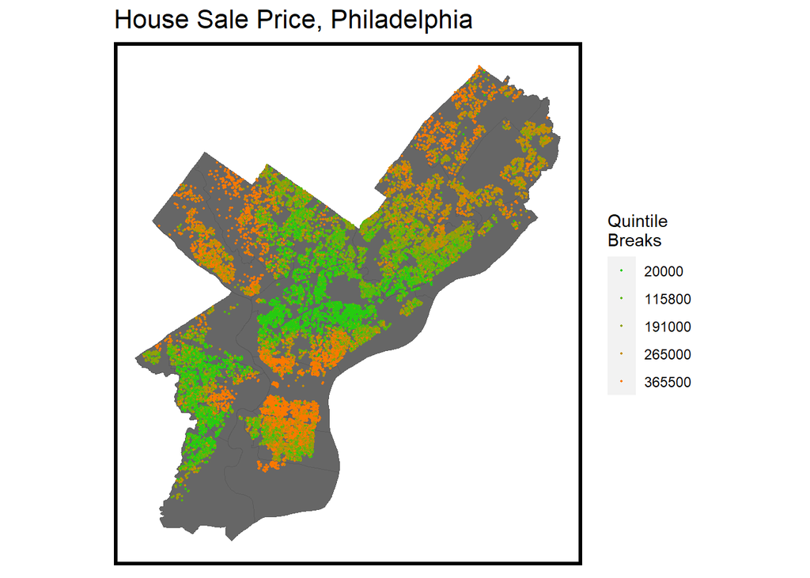

```r
# ggplot, reorder

# Mapping data
ggplot() +
  geom_sf(data = district, fill = "grey40") +
  geom_sf(data = nhoods, aes(colour = q5(sale_price)),
          show.legend = "point", size = .35) +
  scale_colour_manual(values = palette5,
                   labels=qBr(nhoods,"sale_price"),
                   name="Quintile\nBreaks") +
  labs(title="House Sale Price, Philadelphia") +
  mapTheme()
```

#### (2) Exterial Characteristics

```r
# 1.Load crime data
philadelphiCrimes <- read.csv('https://raw.githubusercontent.com/ObjQIAN/MUSA-508-Midterm/main/data/Philadelphia_crime.csv')
crime_codes_set <- c("Weapon Violations", "Thefts", "Robbery Firearm", 'Vandalism/Criminal Mischief', 'Homicide - Criminal ','Homicide - Criminal', 'Burglary Residential')
philadelphiCrimes.sf <-
  philadelphiCrimes %>%
  filter(text_general_code %in% crime_codes_set,
  lat > -1) %>%
  dplyr::select(lat, lng) %>%
  na.omit() %>%
  st_as_sf(coords = c( "lng","lat"), crs = "EPSG:4326") %>%
  st_transform('ESRI:102729') %>%
  distinct()

# 2.Load 311 data and select related variables
call311_codes_set <- c('Illegal Dumping','Abandoned Vehicle','Street Defect','Graffiti Removal','Dangerous Building Complaint','Homeless Encampment Request','Abandoned Bike','Opioid Response Unit')
philadelphia311.sf <- read.csv('https://phl.carto.com/api/v2/sql?filename=public_cases_fc&format=csv&skipfields=cartodb_id,the_geom,the_geom_webmercator&q=SELECT%20*%20FROM%20public_cases_fc%20WHERE%20requested_datetime%20%3E=%20%272022-01-01%27%20AND%20requested_datetime%20%3C%20%272023-01-01%27') %>%
  filter(service_name %in% call311_codes_set,
  lat > -1) %>%
  dplyr::select(lat, lon) %>%
  na.omit() %>%
  st_as_sf(coords = c("lon", "lat"), crs = 4326, agr = "constant") %>%
  st_transform('ESRI:102729')

# 3.Load landmark data
landmark.sf <- st_read('http://data-phl.opendata.arcgis.com/datasets/5146960d4d014f2396cb82f31cd82dfe_0.geojson')%>%
  dplyr::select(geometry) %>%
  st_transform('ESRI:102729')

# 4.Load school data
school.sf <- st_read('https://opendata.arcgis.com/datasets/d46a7e59e2c246c891fbee778759717e_0.geojson')%>%
  dplyr::select(geometry) %>%
  st_transform('ESRI:102729')

# 5.Load college data
college.sf <- st_read(
  'https://opendata.arcgis.com/api/v3/datasets/8ad76bc179cf44bd9b1c23d6f66f57d1_0/downloads/data?format=geojson&spatialRefId=4326')%>%
  dplyr::select(geometry) %>%
  st_transform('ESRI:102729')

# 6.Load hospital data
hospital.sf <- st_read('https://opendata.arcgis.com/datasets/df8dc18412494e5abbb021e2f33057b2_0.geojson')%>%
  dplyr::select(geometry) %>%
  st_transform('ESRI:102729')

# 7.Load Parks and Recreation data
park.sf <- st_read('https://opendata.arcgis.com/datasets/0cdc4a1e86c6463b9600f9d9fca39875_0.geojson')%>%
  dplyr::select(geometry) %>%
  st_transform('ESRI:102729')

# 8.Load market data
market.sf <- st_read('https://opendata.arcgis.com/datasets/53b8a1c653a74c92b2de23a5d7bf04a0_0.geojson')%>%
  dplyr::select(geometry) %>%
  st_transform('ESRI:102729')
```

#### (3) Spatial Characteristics

- Census Data:

```
-   `TotalPop`: ASC total population estimated in each census tract
-   `Whites`: People describing themselves as "white alone" in each census tract
-   `VacantHU`: Vacant house units in each census tract
-   `TotalHU`: Estimate of total housing units in each census tract
-   `FemalBachelors`: Female bachelors in each census tract
-   `MaleBachelors`: Male bachelors in each census tract
-   `MedHHInc`: Median household income ($) in each census tract
-   `MedRent`: Median Rent for properties in each census tract
-   `TotalPoverty`: Population living under the level of poverty in each census tract
```

```r
census_api_key("5c7b1ebb206012789759942ddf1acbb882f937ad", overwrite = TRUE)
```

```r
# Load acs data

acsTractsPHL.2020 <-
  get_acs(geography = "tract",
          variables = c("B25026_001E","B02001_002E",
                        "B25002_003E", "B25002_001E",
                        "B15001_050E","B15001_009E",
                        "B19013_001E","B25058_001E",
                        "B06012_002E"),
          year=2020, state=42, county=101,
          geometry=TRUE, output="wide") %>%
  st_transform('ESRI:102729') %>%
  rename(TotalPop = B25026_001E,
         Whites = B02001_002E,
         VacantHU = B25002_003E,
         TotalHU = B25002_001E,
         FemaleBachelors = B15001_050E,
         MaleBachelors = B15001_009E,
         MedHHInc = B19013_001E,
         MedRent = B25058_001E,
         TotalPoverty = B06012_002E) %>%
  dplyr::select(-NAME, -starts_with("B")) %>%
  mutate(pctWhite = ifelse(TotalPop > 0, Whites / TotalPop,0),
         pctVacant = ifelse(TotalPop > 0, VacantHU / TotalPop,0),
         pctBachelors = ifelse(TotalPop > 0, ((FemaleBachelors + MaleBachelors) / TotalPop),0),
         pctPoverty = ifelse(TotalPop > 0, TotalPoverty / TotalPop, 0),
         year = "2020") %>%
  dplyr::select(-Whites, -VacantHU, -TotalHU, -FemaleBachelors, -MaleBachelors, -TotalPoverty, -year, -GEOID)

nhoods <- st_join(nhoods, acsTractsPHL.2020)
```

### 2.1.2 Feature Engineering

#### (1) Crime Data Set

```r
# Counts of crime per buffer of house sale
nhoods$crimes.Buffer <- nhoods %>%
    st_buffer(660) %>%
    aggregate(mutate(philadelphiCrimes.sf, counter = 1),., sum) %>%
    pull(counter)


## Nearest Neighbor Feature

nhoods <-
  nhoods %>%
    mutate(
      crime_nn1 = nn_function(st_coordinates(nhoods),
                              st_coordinates(philadelphiCrimes.sf), k = 1),

      crime_nn2 = nn_function(st_coordinates(nhoods),
                              st_coordinates(philadelphiCrimes.sf), k = 2),

      crime_nn3 = nn_function(st_coordinates(nhoods),
                              st_coordinates(philadelphiCrimes.sf), k = 3),

      crime_nn4 = nn_function(st_coordinates(nhoods),
                              st_coordinates(philadelphiCrimes.sf), k = 4),

      crime_nn5 = nn_function(st_coordinates(nhoods),
                              st_coordinates(philadelphiCrimes.sf), k = 5))
```

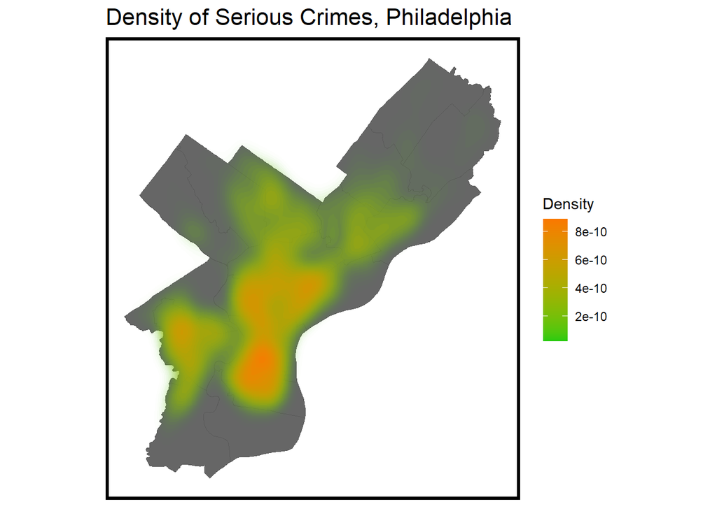

```r
## Plot assault density
ggplot() +
  geom_sf(data = district, fill = "grey40") +
  stat_density2d(data = data.frame(st_coordinates(philadelphiCrimes.sf)),
                 aes(X, Y, fill = ..level.., alpha = ..level..),
                 size = 0.01, bins = 40, geom = 'polygon') +
  scale_fill_gradient(low = "#25CB10", high = "#FA7800", name = "Density") +
  scale_alpha(range = c(0.00, 0.35), guide = "none") +
  labs(title = "Density of Serious Crimes, Philadelphia") +
  mapTheme()
```

From the charts below, `crime_nn5` is the one with the strongest correlation with `sale_price`. We will use crime_nn5 as a factor in the following study.

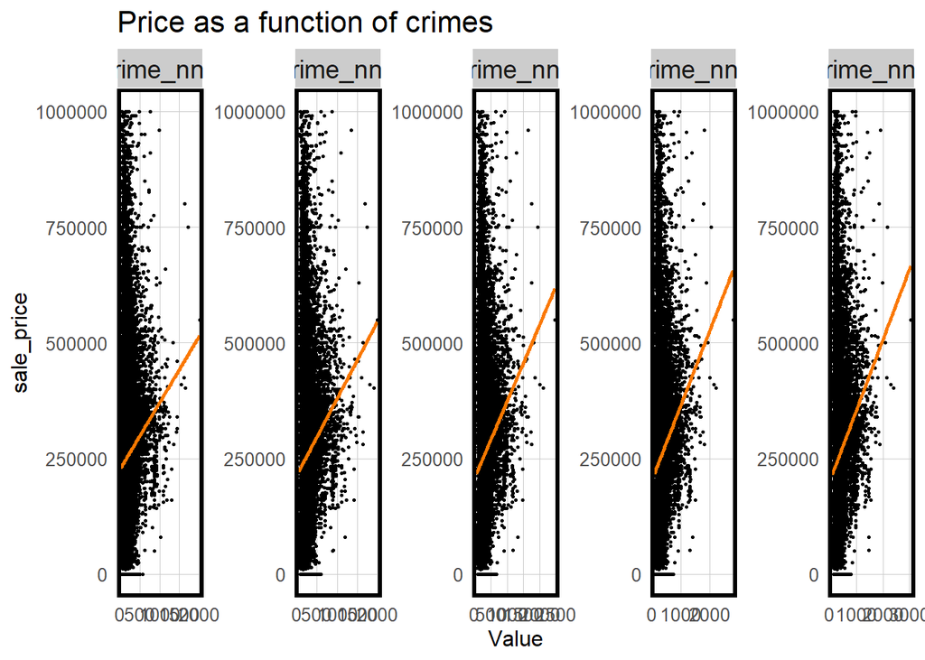

```r
## Crime cor
nhoods %>%
  st_drop_geometry() %>%
  dplyr::select(sale_price, starts_with("crime_")) %>%
  filter(sale_price <= 1000000) %>%
  gather(Variable, Value, -sale_price) %>%
   ggplot(aes(Value, sale_price)) +
     geom_point(size = .5) +
     geom_smooth(data = . %>% filter(sale_price > 0), method = "lm", se=F, colour = "#FA7800") +
     facet_wrap(~Variable, nrow = 1, scales = "free") +
     labs(title = "Price as a function of crimes") +
     plotTheme()
```

#### (2) 311 Data Set

In the figure below, it is shown that the distribution of the number of 311 calls is similar to the hot spots of crime distribution, but is more overall and dispersed.

```r
# Counts of 311 per buffer of house sale
nhoods$p311.Buffer <- nhoods %>%
    st_buffer(660) %>%
    aggregate(mutate(philadelphia311.sf, counter = 1),., sum) %>%
    pull(counter)

## Nearest Neighbor Feature

nhoods <-
  nhoods %>%
    mutate(
      p311_nn1 = nn_function(st_coordinates(nhoods),
                              st_coordinates(philadelphia311.sf), k = 1),

      p311_nn2 = nn_function(st_coordinates(nhoods),
                              st_coordinates(philadelphia311.sf), k = 2),

      p311_nn3 = nn_function(st_coordinates(nhoods),
                              st_coordinates(philadelphia311.sf), k = 3),

      p311_nn4 = nn_function(st_coordinates(nhoods),
                              st_coordinates(philadelphia311.sf), k = 4),

      p311_nn5 = nn_function(st_coordinates(nhoods),
                              st_coordinates(philadelphia311.sf), k = 5))
```

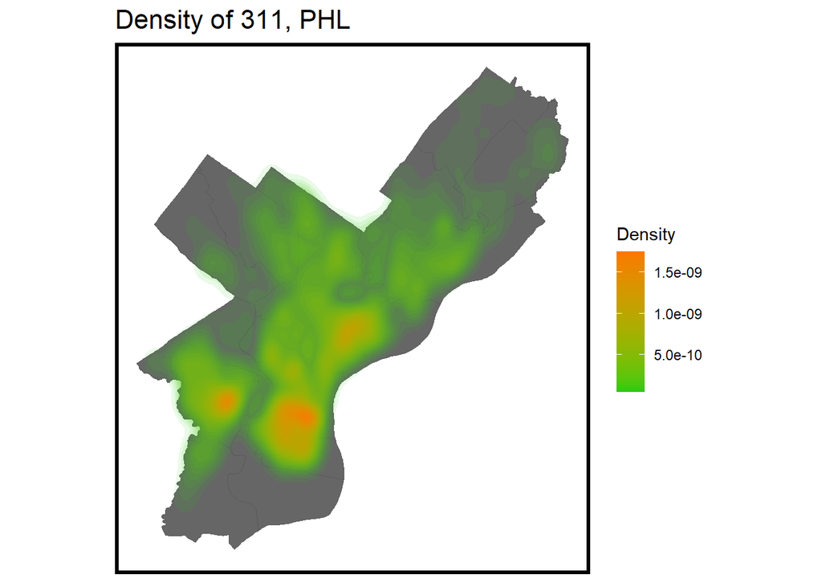

```r
## Plot 311 density
ggplot() + geom_sf(data = district, fill = "grey40") +
  stat_density2d(data = data.frame(st_coordinates(philadelphia311.sf)),
                 aes(X, Y, fill = ..level.., alpha = ..level..),
                 size = 0.01, bins = 40, geom = 'polygon') +
  scale_fill_gradient(low = "#25CB10", high = "#FA7800", name = "Density") +
  scale_alpha(range = c(0.1, 0.35), guide = "none") +
  labs(title = "Density of 311, PHL") +
  mapTheme()
```

From the charts below, `p311_nn5` is the one with the strongest correlation with `sale_price`.

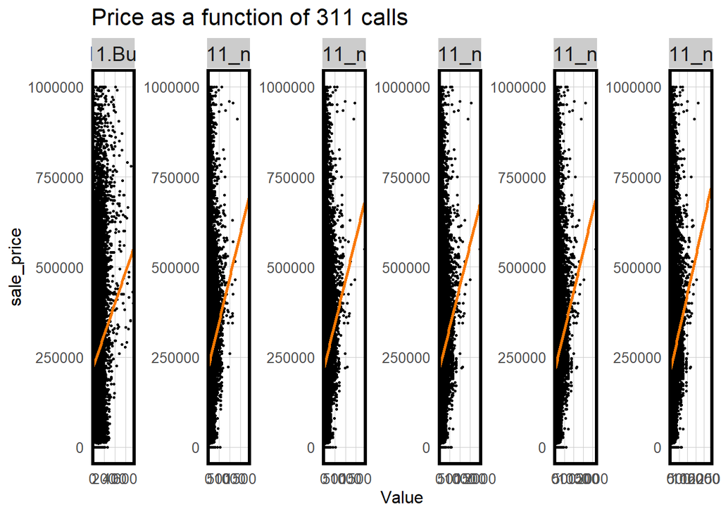

```r
# 311_nn plot

nhoods %>%
  st_drop_geometry() %>%
  dplyr::select(sale_price, starts_with("p311")) %>%
  filter(sale_price <= 1000000) %>%
  gather(Variable, Value, -sale_price) %>%
   ggplot(aes(Value, sale_price)) +
     geom_point(size = .5) +
     geom_smooth(data = . %>% filter(sale_price > 0), method = "lm", se=F, colour = "#FA7800") +
     facet_wrap(~Variable, nrow = 1, scales = "free") +
     labs(title = "Price as a function of 311 calls") +
     plotTheme()
```

#### (3) Amendity data

As we can see in the plots below, `landmark.Buffer`,`school_nn5`,`college.Buffer`,`hospital_nn1`, `market_nn3`have the strongest correlation with `sale_price`.

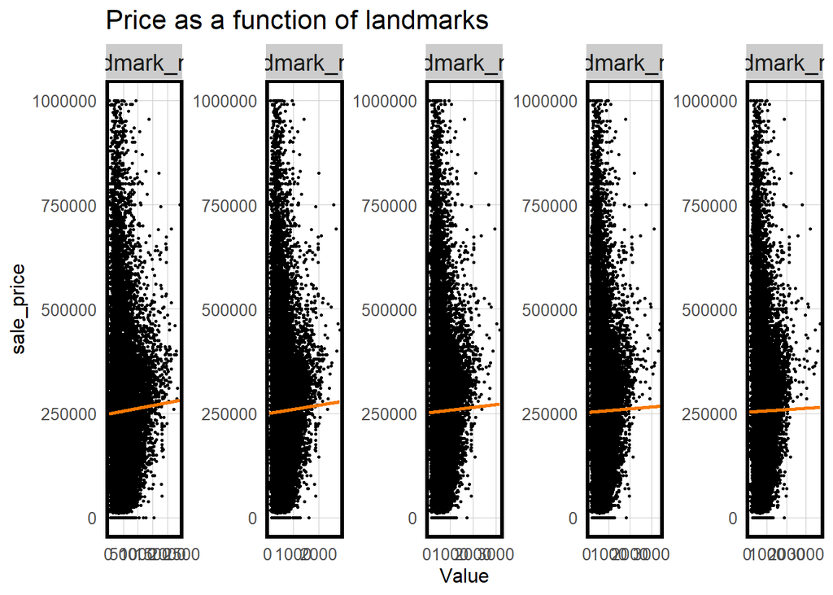

```r
# 1.landmark
nhoods$landmark.Buffer <- nhoods %>%
    st_buffer(660) %>%
    aggregate(mutate(landmark.sf, counter = 1),., sum) %>%
    pull(counter)
nhoods <-
  nhoods %>%
  mutate(
    landmark_nn1 = nn_function(st_coordinates(st_centroid(nhoods)), st_coordinates(st_centroid(landmark.sf)), 1),
    landmark_nn2 = nn_function(st_coordinates(st_centroid(nhoods)), st_coordinates(st_centroid(landmark.sf)), 2),
    landmark_nn3 = nn_function(st_coordinates(st_centroid(nhoods)), st_coordinates(st_centroid(landmark.sf)), 3),
    landmark_nn4 = nn_function(st_coordinates(st_centroid(nhoods)), st_coordinates(st_centroid(landmark.sf)), 4),
    landmark_nn5 = nn_function(st_coordinates(st_centroid(nhoods)), st_coordinates(st_centroid(landmark.sf)), 5))
nhoods %>%
  st_drop_geometry() %>%
  dplyr::select(sale_price, starts_with("landmark_")) %>%
  filter(sale_price <= 1000000) %>%
  gather(Variable, Value, -sale_price) %>%
   ggplot(aes(Value, sale_price)) +
     geom_point(size = .5) +
     geom_smooth(data = . %>% filter(sale_price > 0), method = "lm", se=F, colour = "#FA7800") +
     facet_wrap(~Variable, nrow = 1, scales = "free") +
     labs(title = "Price as a function of landmarks") +
     plotTheme()
```

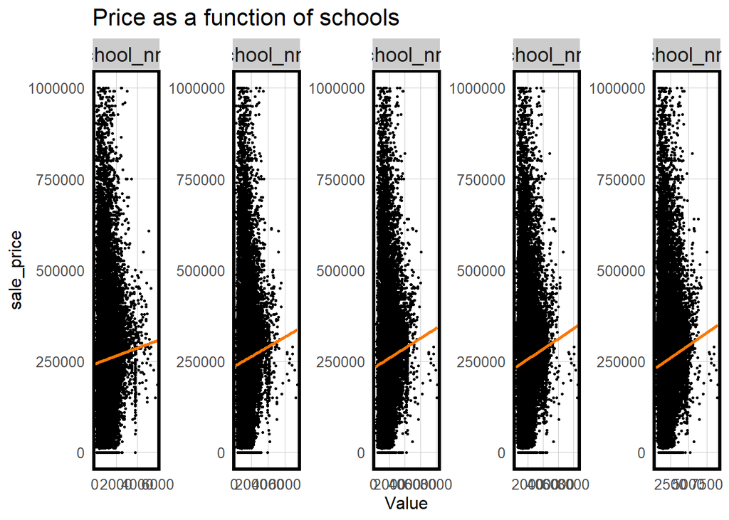

```r
# 2.school
nhoods$school.Buffer <- nhoods %>%
    st_buffer(660) %>%
    aggregate(mutate(school.sf, counter = 1),., sum) %>%
    pull(counter)
nhoods <-
  nhoods %>%
  mutate(
    school_nn1 = nn_function(st_coordinates(st_centroid(nhoods)), st_coordinates(st_centroid(school.sf)), 1),
    school_nn2 = nn_function(st_coordinates(st_centroid(nhoods)), st_coordinates(st_centroid(school.sf)), 2),
    school_nn3 = nn_function(st_coordinates(st_centroid(nhoods)), st_coordinates(st_centroid(school.sf)), 3),
    school_nn4 = nn_function(st_coordinates(st_centroid(nhoods)), st_coordinates(st_centroid(school.sf)), 4),
    school_nn5 = nn_function(st_coordinates(st_centroid(nhoods)), st_coordinates(st_centroid(school.sf)), 5))
nhoods %>%
  st_drop_geometry() %>%
  dplyr::select(sale_price, starts_with("school_")) %>%
  filter(sale_price <= 1000000) %>%
  gather(Variable, Value, -sale_price) %>%
   ggplot(aes(Value, sale_price)) +
     geom_point(size = .5) +
     geom_smooth(data = . %>% filter(sale_price > 0), method = "lm", se=F, colour = "#FA7800") +
     facet_wrap(~Variable, nrow = 1, scales = "free") +
     labs(title = "Price as a function of schools") +
     plotTheme()
```

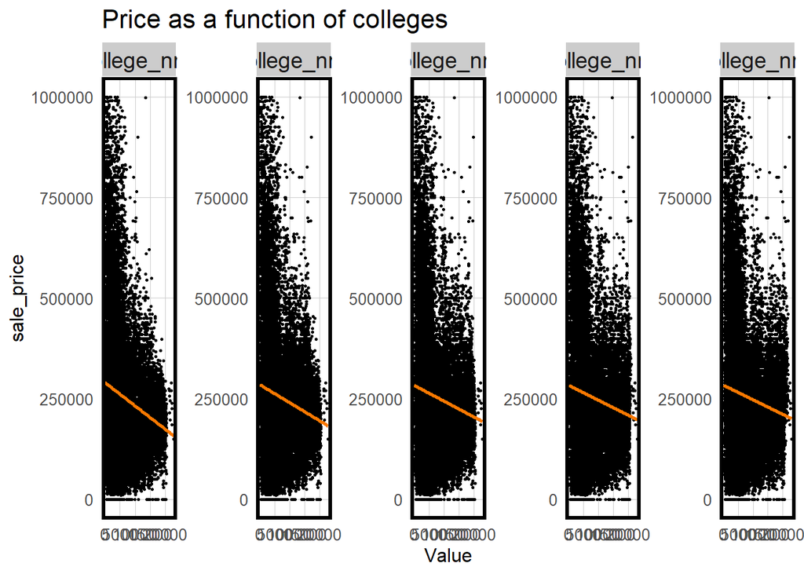

```r
# 3.college
nhoods$college.Buffer <- nhoods %>%
    st_buffer(660) %>%
    aggregate(mutate(college.sf, counter = 1),., sum) %>%
    pull(counter)
nhoods <-
  nhoods %>%
  mutate(
    college_nn1 = nn_function(st_coordinates(st_centroid(nhoods)), st_coordinates(st_centroid(college.sf)), 1),
    college_nn2 = nn_function(st_coordinates(st_centroid(nhoods)), st_coordinates(st_centroid(college.sf)), 2),
    college_nn3 = nn_function(st_coordinates(st_centroid(nhoods)), st_coordinates(st_centroid(college.sf)), 3),
    college_nn4 = nn_function(st_coordinates(st_centroid(nhoods)), st_coordinates(st_centroid(college.sf)), 4),
    college_nn5 = nn_function(st_coordinates(st_centroid(nhoods)), st_coordinates(st_centroid(college.sf)), 5))
nhoods %>%
  st_drop_geometry() %>%
  dplyr::select(sale_price, starts_with("college_")) %>%
  filter(sale_price <= 1000000) %>%
  gather(Variable, Value, -sale_price) %>%
   ggplot(aes(Value, sale_price)) +
     geom_point(size = .5) +
     geom_smooth(data = . %>% filter(sale_price > 0), method = "lm", se=F, colour = "#FA7800") +
     facet_wrap(~Variable, nrow = 1, scales = "free") +
     labs(title = "Price as a function of colleges") +
     plotTheme()
```

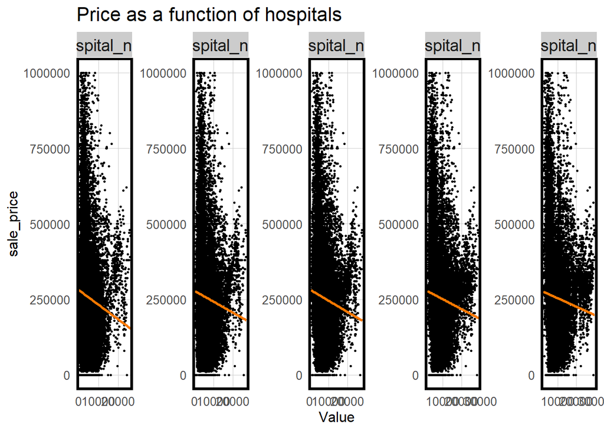

```r
# 4.hospital
nhoods$hospital.Buffer <- nhoods %>%
    st_buffer(660) %>%
    aggregate(mutate(hospital.sf, counter = 1),., sum) %>%
    pull(counter)
nhoods <-
  nhoods %>%
  mutate(
    hospital_nn1 = nn_function(st_coordinates(st_centroid(nhoods)), st_coordinates(st_centroid(hospital.sf)), 1),
    hospital_nn2 = nn_function(st_coordinates(st_centroid(nhoods)), st_coordinates(st_centroid(hospital.sf)), 2),
    hospital_nn3 = nn_function(st_coordinates(st_centroid(nhoods)), st_coordinates(st_centroid(hospital.sf)), 3),
    hospital_nn4 = nn_function(st_coordinates(st_centroid(nhoods)), st_coordinates(st_centroid(hospital.sf)), 4),
    hospital_nn5 = nn_function(st_coordinates(st_centroid(nhoods)), st_coordinates(st_centroid(hospital.sf)), 5))
nhoods %>%
  st_drop_geometry() %>%
  dplyr::select(sale_price, starts_with("hospital_")) %>%
  filter(sale_price <= 1000000) %>%
  gather(Variable, Value, -sale_price) %>%
   ggplot(aes(Value, sale_price)) +
     geom_point(size = .5) +
     geom_smooth(data = . %>% filter(sale_price > 0), method = "lm", se=F, colour = "#FA7800") +
     facet_wrap(~Variable, nrow = 1, scales = "free") +
     labs(title = "Price as a function of hospitals") +
     plotTheme()
```

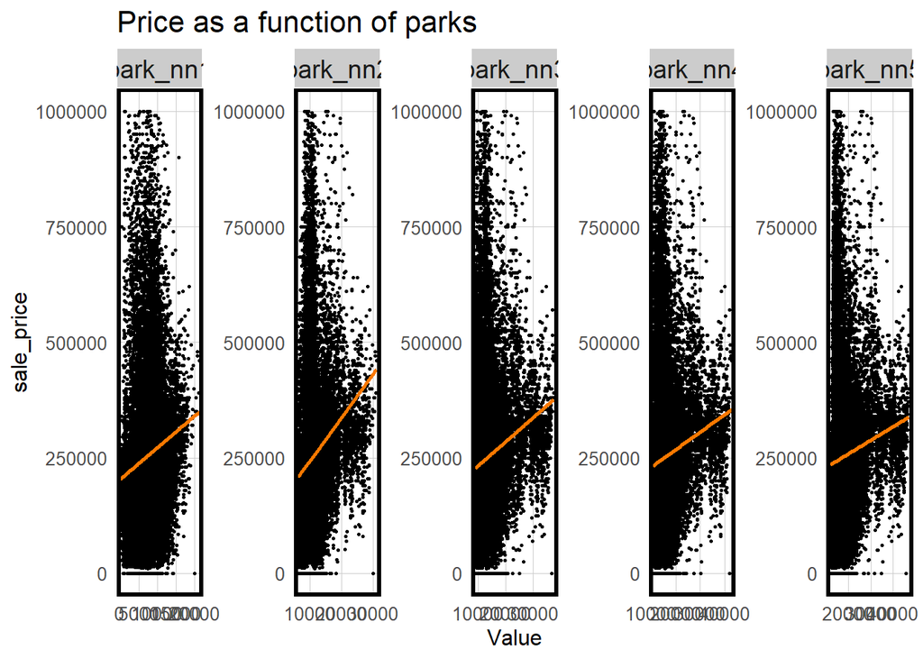

```r
# 5.parks and recreation
nhoods$park.Buffer <- nhoods %>%
    st_buffer(660) %>%
    aggregate(mutate(park.sf, counter = 1),., sum) %>%
    pull(counter)
nhoods <-
  nhoods %>%
  mutate(
    park_nn1 = nn_function(st_coordinates(st_centroid(nhoods)), st_coordinates(st_centroid(park.sf)), 1),
    park_nn2 = nn_function(st_coordinates(st_centroid(nhoods)), st_coordinates(st_centroid(park.sf)), 2),
    park_nn3 = nn_function(st_coordinates(st_centroid(nhoods)), st_coordinates(st_centroid(park.sf)), 3),
    park_nn4 = nn_function(st_coordinates(st_centroid(nhoods)), st_coordinates(st_centroid(park.sf)), 4),
    park_nn5 = nn_function(st_coordinates(st_centroid(nhoods)), st_coordinates(st_centroid(park.sf)), 5))
nhoods %>%
  st_drop_geometry() %>%
  dplyr::select(sale_price, starts_with("park_")) %>%
  filter(sale_price <= 1000000) %>%
  gather(Variable, Value, -sale_price) %>%
   ggplot(aes(Value, sale_price)) +
     geom_point(size = .5) +
     geom_smooth(data = . %>% filter(sale_price > 0), method = "lm", se=F, colour = "#FA7800") +
     facet_wrap(~Variable, nrow = 1, scales = "free") +
     labs(title = "Price as a function of parks") +
     plotTheme()
```

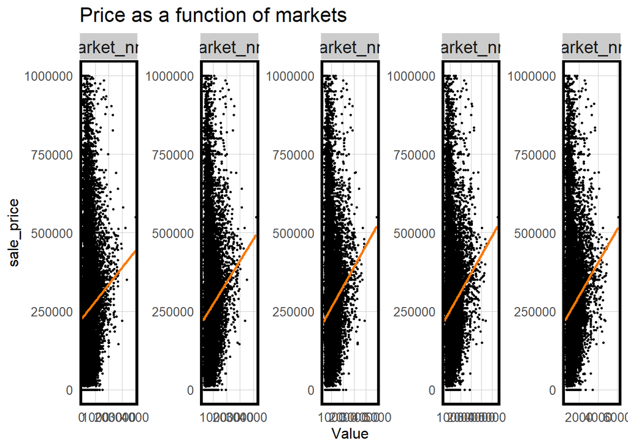

```r
# 6.market
nhoods$market.Buffer <- nhoods %>%
    st_buffer(660) %>%
    aggregate(mutate(market.sf, counter = 1),., sum) %>%
    pull(counter)
nhoods <-
  nhoods %>%
  mutate(
    market_nn1 = nn_function(st_coordinates(st_centroid(nhoods)), st_coordinates(st_centroid(market.sf)), 1),
    market_nn2 = nn_function(st_coordinates(st_centroid(nhoods)), st_coordinates(st_centroid(market.sf)), 2),
    market_nn3 = nn_function(st_coordinates(st_centroid(nhoods)), st_coordinates(st_centroid(market.sf)), 3),
    market_nn4 = nn_function(st_coordinates(st_centroid(nhoods)), st_coordinates(st_centroid(market.sf)), 4),
    market_nn5 = nn_function(st_coordinates(st_centroid(nhoods)), st_coordinates(st_centroid(market.sf)), 5))
nhoods %>%
  st_drop_geometry() %>%
  dplyr::select(sale_price, starts_with("market_")) %>%
  filter(sale_price <= 1000000) %>%
  gather(Variable, Value, -sale_price) %>%
   ggplot(aes(Value, sale_price)) +
     geom_point(size = .5) +
     geom_smooth(data = . %>% filter(sale_price > 0), method = "lm", se=F, colour = "#FA7800") +
     facet_wrap(~Variable, nrow = 1, scales = "free") +
     labs(title = "Price as a function of markets") +
     plotTheme()
```

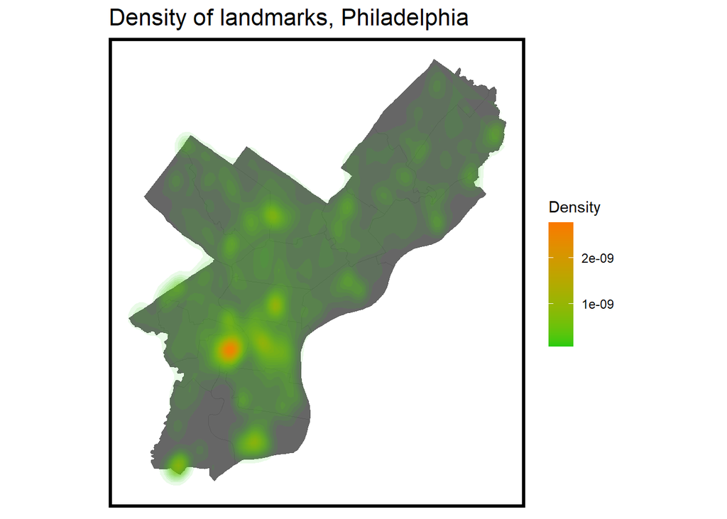

```r
## Plot landmarks density
ggplot() + geom_sf(data = district, fill = "grey40") +
  stat_density2d(data = data.frame(st_coordinates(landmark.sf)),
                 aes(X, Y, fill = ..level.., alpha = ..level..),
                 size = 0.01, bins = 40, geom = 'polygon') +
  scale_fill_gradient(low = "#25CB10", high = "#FA7800", name = "Density") +
  scale_alpha(range = c(0.1, 0.35), guide = "none") +
  labs(title = "Density of landmarks, Philadelphia") +
  mapTheme()
```

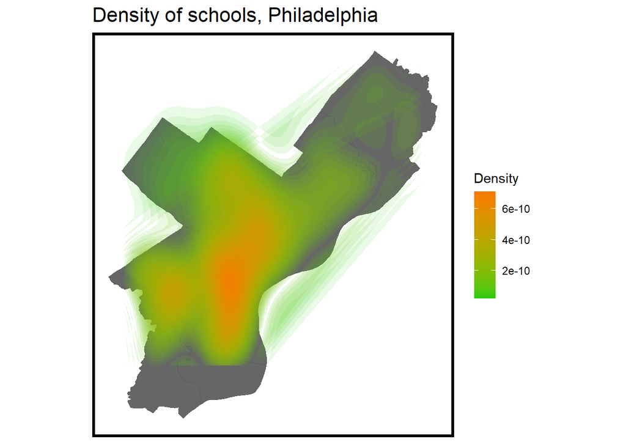

```r
## Plot schools density
ggplot() + geom_sf(data = district, fill = "grey40") +
  stat_density2d(data = data.frame(st_coordinates(school.sf)),
                 aes(X, Y, fill = ..level.., alpha = ..level..),
                 size = 0.01, bins = 40, geom = 'polygon') +
  scale_fill_gradient(low = "#25CB10", high = "#FA7800", name = "Density") +
  scale_alpha(range = c(0.1, 0.35), guide = "none") +
  labs(title = "Density of schools, Philadelphia") +
  mapTheme()
```

```r
#select the data for prediction and training model.
to_predict <-
  nhoods %>%
  dplyr::filter(toPredict == 'CHALLENGE') #Select data for later prediction

to_train <-
  nhoods %>%
  dplyr::filter(toPredict == 'MODELLING') #Select data for training Model
```

### 2.1.3 Summary Statistics

For this part, we summarized and reviewed the data and separated them to Internal Characteristics, External Characteristics, and Spatial Characteristics

#### (1) Internal Characteristics

```r
# all useful columns
feature.list <- to_train %>%
  dplyr::select(sale_price, Age, total_livable_area,
               geographic_ward,garage_spaces,fireplaces, interior_condition,exterior_condition,
               number_of_bathrooms, number_of_bedrooms, number_stories,
               toPredict, zip_code, geometry,
               crimes.Buffer, crime_nn1, crime_nn2, crime_nn3, crime_nn4, crime_nn5,
                 p311.Buffer, p311_nn1, p311_nn2, p311_nn3, p311_nn4, p311_nn5,
                 landmark.Buffer, landmark_nn1, landmark_nn2, landmark_nn3, landmark_nn4, landmark_nn5,
                 school.Buffer, school_nn1, school_nn2, school_nn3, school_nn4, school_nn5,
                 college.Buffer, college_nn1, college_nn2, college_nn3, college_nn4, college_nn5,
                 hospital.Buffer, hospital_nn1, hospital_nn2, hospital_nn3, hospital_nn4, hospital_nn5,
                 park.Buffer, park_nn1, park_nn2, park_nn3, park_nn4, park_nn5,
                 market.Buffer, market_nn1, market_nn2, market_nn3, market_nn4, market_nn5)
```

```r
# 1.internal characteristics

internal.list <-
  to_train %>%
  dplyr:: select( Age, total_livable_area,
                 geographic_ward,garage_spaces,fireplaces, interior_condition,exterior_condition,
                 number_of_bathrooms, number_of_bedrooms, number_stories) %>%
  st_drop_geometry()


stargazer(data = internal.list, type = "html",
          title = " Table.1 Summary Statistics of Internal Characteristics ",
          header = FALSE,
          single.row = TRUE)
```

[output not shown]

#### (2) External Characteristics

```r
# 2.external characteristics1
external.list <- to_train %>%
  dplyr:: select(crimes.Buffer, crime_nn1, crime_nn2, crime_nn3, crime_nn4, crime_nn5,
                 p311.Buffer, p311_nn1, p311_nn2, p311_nn3, p311_nn4, p311_nn5,
                 landmark.Buffer, landmark_nn1, landmark_nn2, landmark_nn3, landmark_nn4, landmark_nn5,
                 school.Buffer, school_nn1, school_nn2, school_nn3, school_nn4, school_nn5,
                 college.Buffer, college_nn1, college_nn2, college_nn3, college_nn4, college_nn5,
                 hospital.Buffer, hospital_nn1, hospital_nn2, hospital_nn3, hospital_nn4, hospital_nn5,
                 park.Buffer, park_nn1, park_nn2, park_nn3, park_nn4, park_nn5,
                 market.Buffer, market_nn1, market_nn2, market_nn3, market_nn4, market_nn5) %>%
  st_drop_geometry()

stargazer(data = external.list, type = "html",
          title = " Table.2 Summary Statistics of External Characteristics1 ",
          header = FALSE,
          single.row = TRUE)
```

[output not shown]

#### (3) Spatial Characteristics

```r
# 3. external characteristics2 - acs features

census.list <- to_train %>%
  dplyr:: select( TotalPop, MedRent ,MedHHInc, pctWhite, pctVacant, pctBachelors, pctPoverty)

stargazer(census.list, type = "html",
          title = "Table.3 Summary Statistics of External Characteristics - Census Data ",
          header = FALSE,
          single.row = TRUE)
```

[output not shown]

# 3 Analyzing Associations

## 3.1 Sale Price as a Function of Numeric Features

We use the scatter plot to initially determine whether the following Numeric Features are suitable as our variables. As can be seen from the chart below, some of the features that may be useful are: `Age`, `depth`, `frontage`, `total_livable_area`, `geographic_ward`, `garage_spaces`, `crime_nn5`,`p311_nn5`, `landmark.Buffer`,`school_nn5`,`college.Buffer`,`hospital_nn1`, `market_nn3`.

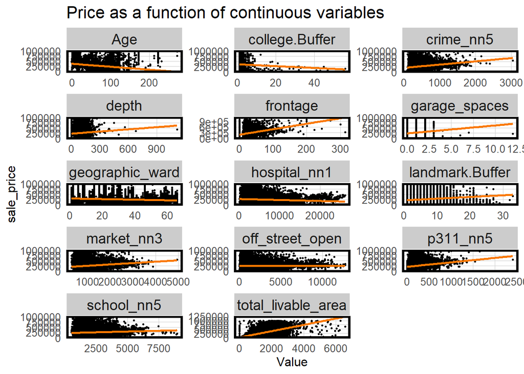

```r
## Home Features cor

st_drop_geometry(to_train) %>%
  dplyr::select(sale_price, total_livable_area, Age,
                depth, frontage, off_street_open, geographic_ward, garage_spaces,
                crime_nn5, p311_nn5, landmark.Buffer, school_nn5, college.Buffer, hospital_nn1, market_nn3) %>%
  filter(sale_price <= 1000000, Age < 500, total_livable_area <10000, frontage < 500) %>%
  gather(Variable, Value, -sale_price) %>%
   ggplot(aes(Value, sale_price)) +
     geom_point(size = .5) +
    geom_smooth(data = . %>% filter(sale_price >0), method = "lm", se=F, colour = "#FA7800") +
     facet_wrap(~Variable, ncol = 3, scales = "free") +
     labs(title = "Price as a function of continuous variables") +
     plotTheme()
```

## 3.2 Sale Price as a Function of Categorical Features

We use the histograms to initially determine whether the following categorical features are suitable as our variables. As can be seen from the chart below, some of the features that may be useful are: `exterior_condition`, `fireplaces`, `interior_condition`, `number_of_bathrooms`, `number_of_bedrooms`, `number_stories`.

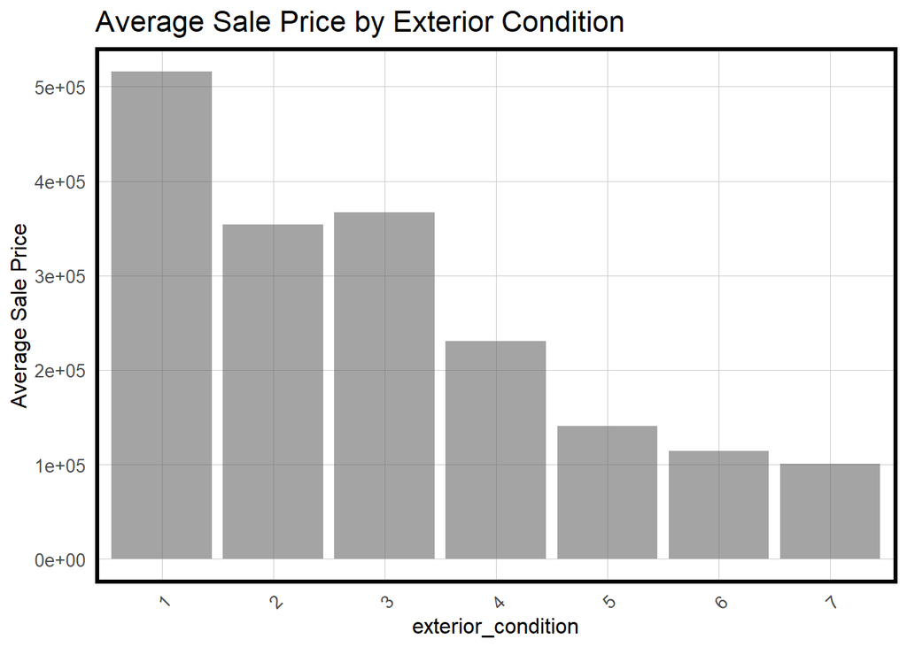

```r
to_train %>%
  dplyr::select(sale_price, exterior_condition) %>%
  mutate(exterior_condition = as.factor(exterior_condition)) %>%
  filter(sale_price <= 1000000) %>%
  group_by(exterior_condition) %>%
  summarize(avg_sale_price = mean(sale_price)) %>%
  ggplot(aes(x = exterior_condition, y = avg_sale_price,alpha = 0.3)) +
    geom_bar(stat = "identity") +
    labs(
      title = "Average Sale Price by Exterior Condition",
      y = "Average Sale Price"
    ) +
    plotTheme() +
    theme(axis.text.x = element_text(angle = 45, hjust = 1),legend.position = 'none')
```

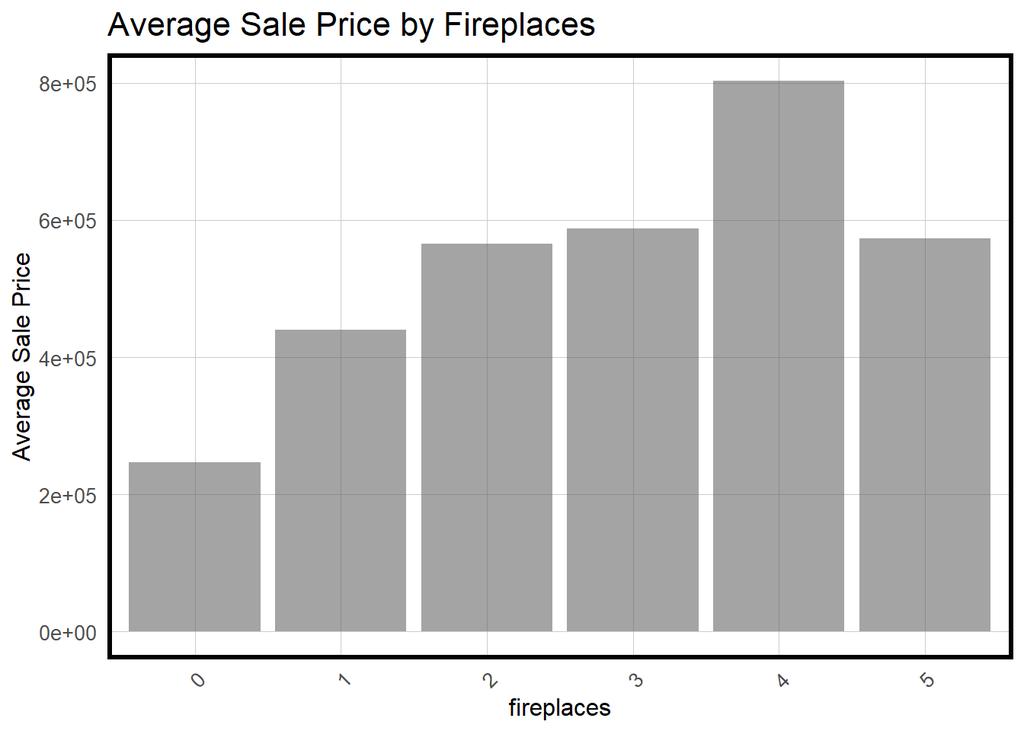

```r
to_train %>%
  dplyr::select(sale_price, fireplaces) %>%
  mutate(fireplaces = as.factor(fireplaces)) %>%
  filter(sale_price <= 1000000) %>%
  filter(!is.na(fireplaces)) %>%
  group_by(fireplaces) %>%
  summarize(avg_sale_price = mean(sale_price)) %>%
  ggplot(aes(x = fireplaces, y = avg_sale_price,alpha = 0.3)) +
    geom_bar(stat = "identity") +
    labs(
      title = "Average Sale Price by Fireplaces",
      y = "Average Sale Price"
    ) +
    plotTheme() +
    theme(axis.text.x = element_text(angle = 45, hjust = 1),legend.position = 'none')
```

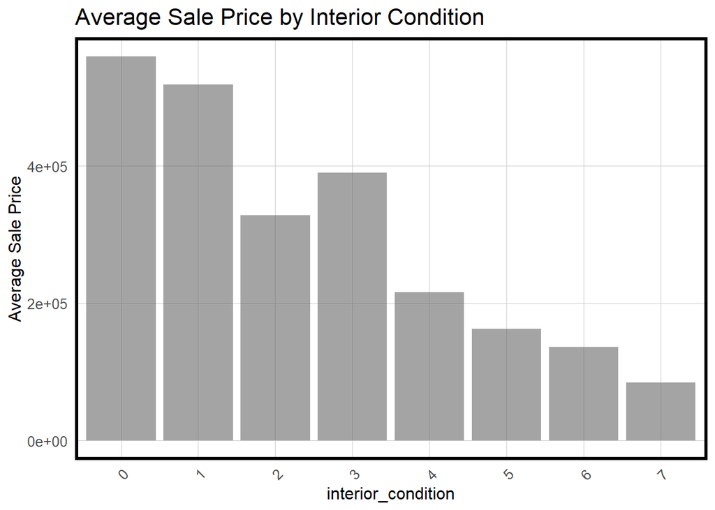

```r
to_train %>%
  dplyr::select(sale_price, interior_condition) %>%
  mutate(interior_condition = as.factor(interior_condition)) %>%
  filter(sale_price <= 1000000) %>%
  filter(!is.na(interior_condition)) %>%
  group_by(interior_condition) %>%
  summarize(avg_sale_price = mean(sale_price)) %>%
  ggplot(aes(x = interior_condition, y = avg_sale_price,alpha = 0.3)) +
    geom_bar(stat = "identity") +
    labs(
      title = "Average Sale Price by Interior Condition",
      y = "Average Sale Price"
    ) +
    plotTheme() +
    theme(axis.text.x = element_text(angle = 45, hjust = 1),legend.position = 'none')
```

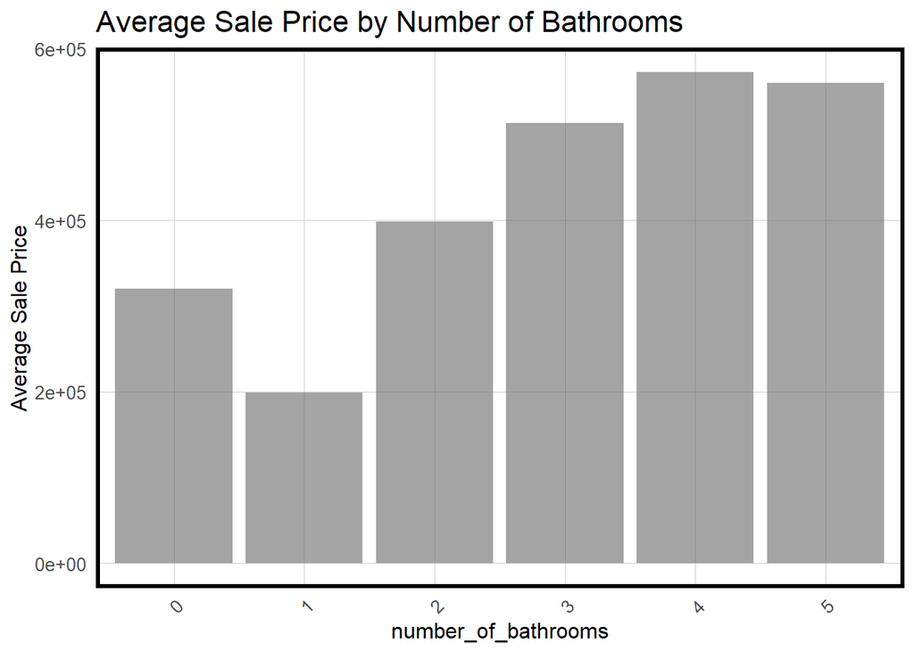

```r
to_train %>%
  dplyr::select(sale_price, number_of_bathrooms) %>%
  mutate(number_of_bathrooms = as.factor(number_of_bathrooms)) %>%
  filter(sale_price <= 1000000) %>%
  filter(!is.na(number_of_bathrooms)) %>%
  group_by(number_of_bathrooms) %>%
  summarize(avg_sale_price = mean(sale_price)) %>%
  ggplot(aes(x = number_of_bathrooms, y = avg_sale_price,alpha = 0.3)) +
    geom_bar(stat = "identity") +
    labs(
      title = "Average Sale Price by Number of Bathrooms",
      y = "Average Sale Price"
    ) +
    plotTheme() +
    theme(axis.text.x = element_text(angle = 45, hjust = 1),legend.position = 'none')
```

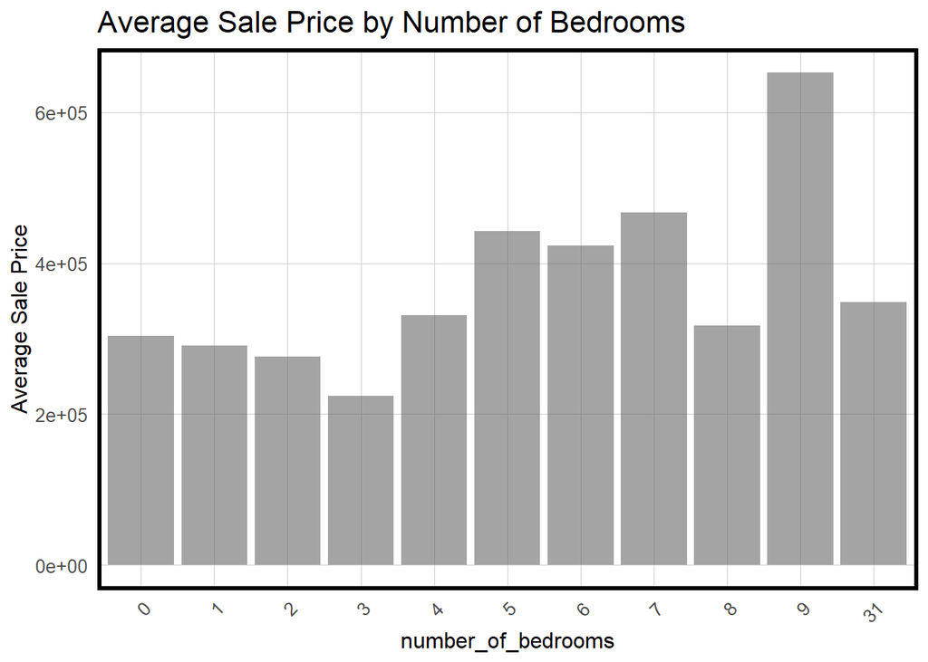

```r
to_train %>%
  dplyr::select(sale_price, number_of_bedrooms) %>%
  mutate(number_of_bedrooms = as.factor(number_of_bedrooms)) %>%
  filter(sale_price <= 1000000) %>%
  filter(!is.na(number_of_bedrooms)) %>%
  group_by(number_of_bedrooms) %>%
  summarize(avg_sale_price = mean(sale_price)) %>%
  ggplot(aes(x = number_of_bedrooms, y = avg_sale_price,alpha = 0.3)) +
    geom_bar(stat = "identity") +
    labs(
      title = "Average Sale Price by Number of Bedrooms",
      y = "Average Sale Price"
    ) +
    plotTheme() +
    theme(axis.text.x = element_text(angle = 45, hjust = 1),legend.position = 'none')
```

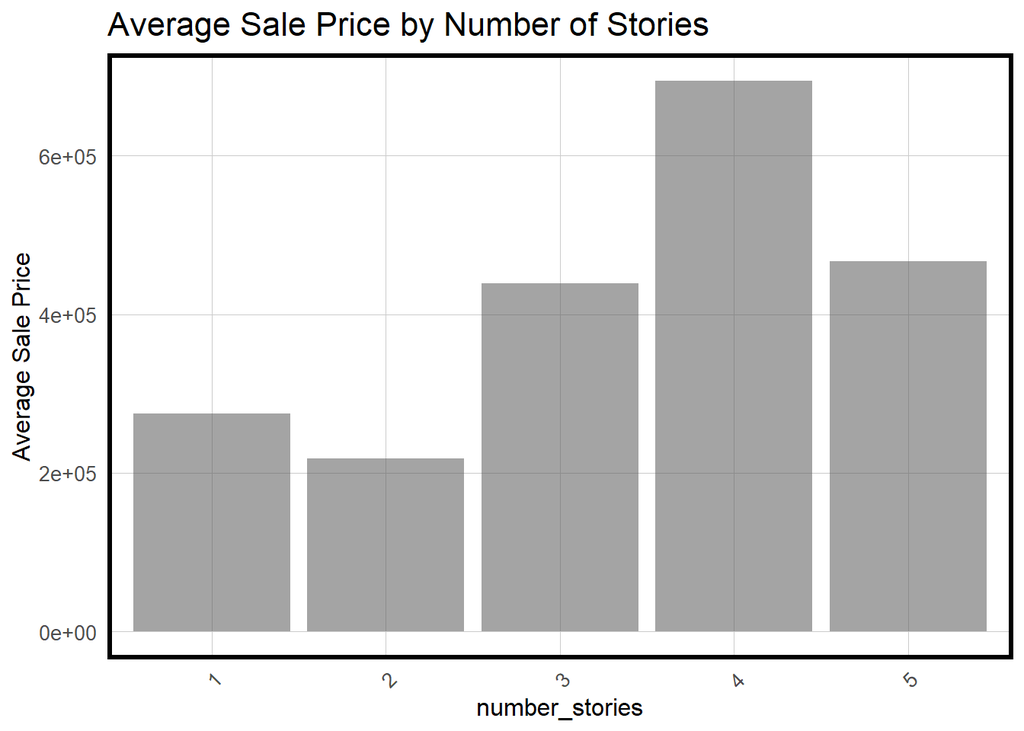

```r
to_train %>%
  dplyr::select(sale_price, number_stories) %>%
  mutate(number_stories = as.factor(number_stories)) %>%
  filter(sale_price <= 1000000) %>%
  filter(!is.na(number_stories)) %>%
  group_by(number_stories) %>%
  summarize(avg_sale_price = mean(sale_price)) %>%
  ggplot(aes(x = number_stories, y = avg_sale_price,alpha = 0.3)) +
    geom_bar(stat = "identity") +
    labs(
      title = "Average Sale Price by Number of Stories",
      y = "Average Sale Price"
    ) +
    plotTheme() +
    theme(axis.text.x = element_text(angle = 45, hjust = 1),legend.position = 'none')
```

```r
# add reclassified data
to_train <- to_train %>%
  mutate(
    exterior_condition_re = case_when(
      exterior_condition %in% 1:3 ~ 1,
      exterior_condition %in% 4:5 ~ 2,
      exterior_condition %in% 6:7 ~ 3
    )
  ) %>%
  mutate(
    fireplaces_re = case_when(
      fireplaces %in% 0:1 ~ 1,
      fireplaces == 2     ~ 2,
      fireplaces %in% 3:5 ~ 3
    )
  ) %>%
  mutate(
    interior_condition_re = case_when(
      interior_condition %in% 0:2 ~ 1,
      interior_condition %in% 3:4 ~ 2,
      interior_condition %in% 5:7 ~ 3
    )
  ) %>%
  mutate(
    number_of_bathrooms_re = case_when(
      number_of_bathrooms ==0      ~ 1,
      number_of_bathrooms %in% 1:2 ~ 2,
      number_of_bathrooms %in% 3:6 ~ 3
    )
  ) %>%
  mutate(
    number_of_bedrooms_re = case_when(
      number_of_bedrooms %in% 0:1 ~ 1,
      number_of_bedrooms %in% 2:3 ~ 2,
      number_of_bedrooms %in% 4:31 ~ 3
    )
  )%>%
  mutate(
    number_stories_re = case_when(
      number_stories == 1     ~ 1,
      number_stories == 2     ~ 2,
      number_stories %in% 3:5 ~ 3
    )
  )

philly_sub_200k <- st_drop_geometry(to_train) %>%
filter(sale_price <= 2000000, total_livable_area < 10000, total_livable_area > 0)
```

## 3.3 Select Variables

In order to prevent the selected features from having too strong correlations between them and affecting the regression results, we use a correlation matrix to provide us with pairwise correlations for each set of features in the data, and use Pearson’s r - Correlation Coefficient to Look at the contribution of each variable.

### 3.3.1 Correlation matrix

#### (1) Interial Characteristics

The correlation matrix reveals that other than a few elements that exhibit a strong correlation with their reclassified counterparts, there is a notably robust positive correlation between `number_of_bathrooms` and `number_of_bedrooms`, while the remaining features show no significant correlations.

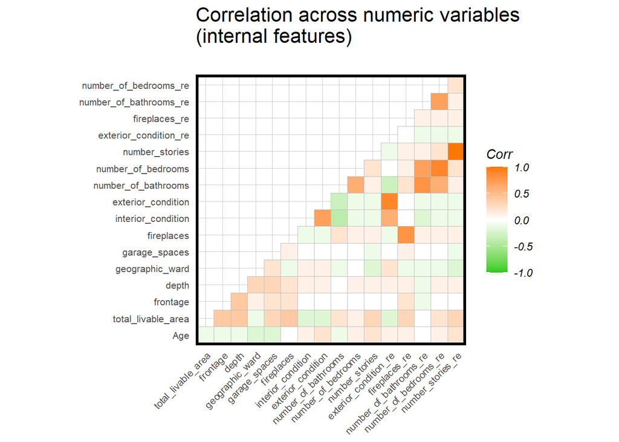

```r
internal.list <- to_train %>%
  dplyr:: select(Age, total_livable_area, frontage, depth,
                 geographic_ward,garage_spaces,fireplaces, interior_condition,exterior_condition,
                 number_of_bathrooms, number_of_bedrooms, number_stories,
                 exterior_condition_re, fireplaces_re, number_of_bathrooms_re, number_of_bedrooms_re,number_stories_re ) %>%
  st_drop_geometry()

numericVars.internal <-
  select_if(internal.list, is.numeric) %>%
  na.omit()

ggcorrplot(
  round(cor(numericVars.internal), 1),
  p.mat = cor_pmat(numericVars.internal),
  colors = c("#25CB10", "white", "#FA7800"),
  lab_size = 1,
  tl.cex = 8,
  type="lower",
  insig = "blank") +
    labs(title = "Correlation across numeric variables\n(internal features)\n") +
  plotTheme()
```

```r
BED_Reg <- lm(sale_price ~ number_of_bedrooms, data = philly_sub_200k)
summary(BED_Reg)

BATH_Reg <- lm(sale_price ~ number_of_bathrooms, data = philly_sub_200k)
summary(BATH_Reg)
```

[output not shown]

#### (2) Exterial Characteristics

In order to make the results more intuitive, we put the filtered features (`crime_nn5`,`p311_nn5`,`landmark.Buffer`,`school_nn5`,`college.Buffer`,`hospital_nn1`, `market_nn3`) that has a stronger correlation with sale_price into the plot.

In the plot below, most of them do not have correlation, while `landmark.Buffer` and `market_nn3` have a positive correlation.

[figure not shown]

```r
external.list <- to_train %>%
  dplyr:: select(crime_nn5,
                 p311_nn5,
                 landmark.Buffer,
                 school_nn5,college.Buffer,
                 hospital.Buffer, hospital_nn1,
                 park_nn2, market_nn3) %>%
  st_drop_geometry()
numericVars.external <-
  select_if(external.list, is.numeric) %>%
  na.omit()

ggcorrplot(
  round(cor(numericVars.external ), 1),
  p.mat = cor_pmat(numericVars.external ),
  colors = c("#25CB10", "white", "#FA7800"),
  lab_size = 1,
  tl.cex = 8,
  type="lower",
  insig = "blank") +
    labs(title = "Correlation across numeric variables\n(internal features)\n") +
  plotTheme()
```

#### (3) Spatial Characteristics

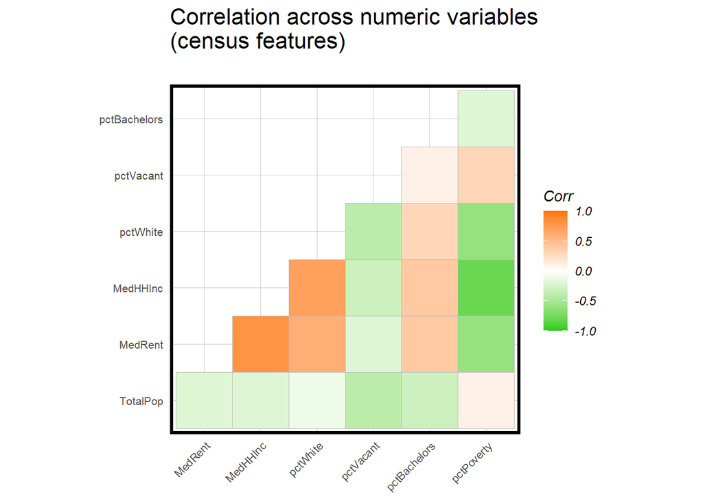

```r
numericVars.spatial <-
  select_if(census.list, is.numeric) %>%
  na.omit() %>%
  st_drop_geometry()

ggcorrplot(
  round(cor(numericVars.spatial ), 1),
  p.mat = cor_pmat(numericVars.spatial),
  colors = c("#25CB10", "white", "#FA7800"),
  lab_size = 1,
  tl.cex = 8,
  type="lower",
  insig = "blank") +
    labs(title = "Correlation across numeric variables\n(census features)\n") +
  plotTheme()
```

### 3.3.2 Univarite correlation with Pearson’s r - Correlation Coefficient

```r
cor.test(philly_sub_200k$total_livable_area,
         philly_sub_200k$sale_price,
         method = "pearson")
```

```
##
##  Pearson's product-moment correlation
##
## data:  philly_sub_200k$total_livable_area and philly_sub_200k$sale_price
## t = 107.7, df = 23683, p-value < 2.2e-16
## alternative hypothesis: true correlation is not equal to 0
## 95 percent confidence interval:
##  0.5647452 0.5818438
## sample estimates:
##       cor
## 0.5733569
```

```r
livingReg <- lm(sale_price ~ total_livable_area, data = philly_sub_200k)

summary(livingReg)
```

```
##
## Call:
## lm(formula = sale_price ~ total_livable_area, data = philly_sub_200k)
##
## Residuals:
##      Min       1Q   Median       3Q      Max
## -1203042   -98386   -17240    70728  1467884
##
## Coefficients:
##                      Estimate Std. Error t value Pr(>|t|)
## (Intercept)        -41433.984   3056.927  -13.55   <2e-16 ***
## total_livable_area    232.139      2.156  107.69   <2e-16 ***
## ---
## Signif. codes:  0 '***' 0.001 '**' 0.01 '*' 0.05 '.' 0.1 ' ' 1
##
## Residual standard error: 165700 on 23683 degrees of freedom
## Multiple R-squared:  0.3287, Adjusted R-squared:  0.3287
## F-statistic: 1.16e+04 on 1 and 23683 DF,  p-value: < 2.2e-16
```

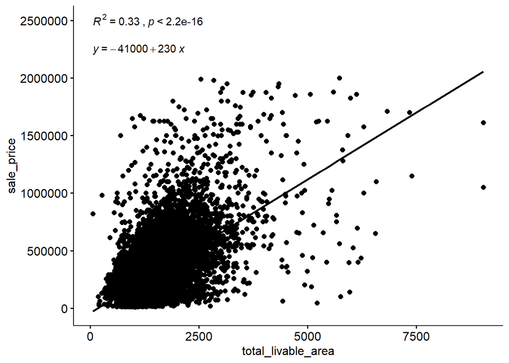

```r
ggscatter(philly_sub_200k,
          x = "total_livable_area",
          y = "sale_price",
          add = "reg.line") +
  stat_cor(aes(label = paste(..rr.label.., ..p.label.., sep = "~`,`~")), label.y = 2500000) +
  stat_regline_equation(label.y = 2250000)
```

# 4 Results

## 4.1 Multivariate OLS Regression

### 4.1.1 Table of results (training set)

```r
reg1 <- lm(sale_price ~ ., data = philly_sub_200k %>%
                                 dplyr::select(sale_price, Age, total_livable_area,
                                               geographic_ward,garage_spaces,
                                               fireplaces, interior_condition,exterior_condition, number_of_bathrooms,
                                               number_of_bedrooms, number_stories,
                                               crime_nn5,p311_nn5,landmark.Buffer,
                                               school_nn5,college.Buffer,
                                               hospital.Buffer, hospital_nn1,
                                               park_nn2, market_nn3,
                                               TotalPop, MedRent ,MedHHInc, pctWhite, pctVacant, pctBachelors, pctPoverty))

summary(reg1)
```

```
##
## Call:
## lm(formula = sale_price ~ ., data = philly_sub_200k %>% dplyr::select(sale_price,
##     Age, total_livable_area, geographic_ward, garage_spaces,
##     fireplaces, interior_condition, exterior_condition, number_of_bathrooms,
##     number_of_bedrooms, number_stories, crime_nn5, p311_nn5,
##     landmark.Buffer, school_nn5, college.Buffer, hospital.Buffer,
##     hospital_nn1, park_nn2, market_nn3, TotalPop, MedRent, MedHHInc,
##     pctWhite, pctVacant, pctBachelors, pctPoverty))
##
## Residuals:
##     Min      1Q  Median      3Q     Max
## -204391  -54523       0   43567  155312
##
## Coefficients:
##                       Estimate Std. Error t value Pr(>|t|)
## (Intercept)         -9.837e+04  3.094e+05  -0.318 0.751653
## Age                  7.189e+02  4.190e+02   1.716 0.091538 .
## total_livable_area   1.844e+02  3.218e+01   5.731 3.77e-07 ***
## geographic_ward      2.631e+03  2.819e+03   0.933 0.354459
## garage_spaces        3.229e+05  4.997e+04   6.463 2.33e-08 ***
## fireplaces           4.974e+04  3.195e+04   1.557 0.125016
## interior_condition   1.416e+04  2.543e+04   0.557 0.579776
## exterior_condition  -1.011e+05  2.570e+04  -3.933 0.000227 ***
## number_of_bathrooms  1.892e+04  2.351e+04   0.805 0.424122
## number_of_bedrooms   1.151e+03  1.423e+04   0.081 0.935859
## number_stories       4.380e+04  2.855e+04   1.534 0.130471
## crime_nn5            2.245e+02  3.813e+02   0.589 0.558289
## p311_nn5             3.297e+02  2.908e+02   1.134 0.261589
## landmark.Buffer      2.159e+04  5.232e+03   4.126 0.000119 ***
## school_nn5           9.489e+01  7.401e+01   1.282 0.204868
## college.Buffer       4.879e+02  2.530e+03   0.193 0.847746
## hospital.Buffer     -1.705e+04  1.239e+05  -0.138 0.891018
## hospital_nn1        -4.545e+01  9.351e+01  -0.486 0.628789
## park_nn2            -5.660e+01  4.071e+01  -1.390 0.169756
## market_nn3          -7.353e+02  2.629e+02  -2.797 0.006993 **
## TotalPop             5.360e+01  2.279e+01   2.352 0.022079 *
## MedRent             -4.391e+02  2.214e+02  -1.983 0.052065 .
## MedHHInc             1.571e+01  3.109e+00   5.052 4.66e-06 ***
## pctWhite             9.551e+04  2.163e+05   0.442 0.660423
## pctVacant           -8.135e+05  8.807e+05  -0.924 0.359449
## pctBachelors         1.590e+06  6.558e+05   2.425 0.018466 *
## pctPoverty           1.039e+06  3.600e+05   2.886 0.005476 **
## ---
## Signif. codes:  0 '***' 0.001 '**' 0.01 '*' 0.05 '.' 0.1 ' ' 1
##
## Residual standard error: 89660 on 58 degrees of freedom
##   (因为不存在，23600个观察量被删除了)
## Multiple R-squared:  0.9438, Adjusted R-squared:  0.9186
## F-statistic: 37.47 on 26 and 58 DF,  p-value: < 2.2e-16
```

```r
stargazer(reg1, type = "html",
          title = "Table 4.1 Summary Statistics of Model 1 ",
          header = FALSE,
          single.row = TRUE)
```

```
##
## <table style="text-align:center"><caption><strong>Table 4.1 Summary Statistics of Model 1</strong></caption>
## <tr><td colspan="2" style="border-bottom: 1px solid black"></td></tr><tr><td style="text-align:left"></td><td><em>Dependent variable:</em></td></tr>
## <tr><td></td><td colspan="1" style="border-bottom: 1px solid black"></td></tr>
## <tr><td style="text-align:left"></td><td>sale_price</td></tr>
## <tr><td colspan="2" style="border-bottom: 1px solid black"></td></tr><tr><td style="text-align:left">Age</td><td>718.853<sup>*</sup> (418.962)</td></tr>
## <tr><td style="text-align:left">total_livable_area</td><td>184.441<sup>***</sup> (32.183)</td></tr>
## <tr><td style="text-align:left">geographic_ward</td><td>2,631.491 (2,819.114)</td></tr>
## <tr><td style="text-align:left">garage_spaces</td><td>322,945.400<sup>***</sup> (49,969.930)</td></tr>
## <tr><td style="text-align:left">fireplaces</td><td>49,735.890 (31,952.500)</td></tr>
## <tr><td style="text-align:left">interior_condition</td><td>14,159.330 (25,427.770)</td></tr>
## <tr><td style="text-align:left">exterior_condition</td><td>-101,054.500<sup>***</sup> (25,696.430)</td></tr>
## <tr><td style="text-align:left">number_of_bathrooms</td><td>18,924.400 (23,509.300)</td></tr>
## <tr><td style="text-align:left">number_of_bedrooms</td><td>1,150.516 (14,234.580)</td></tr>
## <tr><td style="text-align:left">number_stories</td><td>43,799.070 (28,552.550)</td></tr>
## <tr><td style="text-align:left">crime_nn5</td><td>224.532 (381.346)</td></tr>
## <tr><td style="text-align:left">p311_nn5</td><td>329.706 (290.826)</td></tr>
## <tr><td style="text-align:left">landmark.Buffer</td><td>21,589.980<sup>***</sup> (5,232.446)</td></tr>
## <tr><td style="text-align:left">school_nn5</td><td>94.893 (74.007)</td></tr>
## <tr><td style="text-align:left">college.Buffer</td><td>487.933 (2,530.049)</td></tr>
## <tr><td style="text-align:left">hospital.Buffer</td><td>-17,045.560 (123,860.100)</td></tr>
## <tr><td style="text-align:left">hospital_nn1</td><td>-45.449 (93.514)</td></tr>
## <tr><td style="text-align:left">park_nn2</td><td>-56.602 (40.712)</td></tr>
## <tr><td style="text-align:left">market_nn3</td><td>-735.275<sup>***</sup> (262.913)</td></tr>
## <tr><td style="text-align:left">TotalPop</td><td>53.602<sup>**</sup> (22.788)</td></tr>
## <tr><td style="text-align:left">MedRent</td><td>-439.078<sup>*</sup> (221.377)</td></tr>
## <tr><td style="text-align:left">MedHHInc</td><td>15.706<sup>***</sup> (3.109)</td></tr>
## <tr><td style="text-align:left">pctWhite</td><td>95,507.200 (216,277.100)</td></tr>
## <tr><td style="text-align:left">pctVacant</td><td>-813,525.600 (880,687.200)</td></tr>
## <tr><td style="text-align:left">pctBachelors</td><td>1,590,093.000<sup>**</sup> (655,842.200)</td></tr>
## <tr><td style="text-align:left">pctPoverty</td><td>1,038,885.000<sup>***</sup> (360,010.500)</td></tr>
## <tr><td style="text-align:left">Constant</td><td>-98,374.870 (309,387.900)</td></tr>
## <tr><td colspan="2" style="border-bottom: 1px solid black"></td></tr><tr><td style="text-align:left">Observations</td><td>85</td></tr>
## <tr><td style="text-align:left">R<sup>2</sup></td><td>0.944</td></tr>
## <tr><td style="text-align:left">Adjusted R<sup>2</sup></td><td>0.919</td></tr>
## <tr><td style="text-align:left">Residual Std. Error</td><td>89,656.610 (df = 58)</td></tr>
## <tr><td style="text-align:left">F Statistic</td><td>37.472<sup>***</sup> (df = 26; 58)</td></tr>
## <tr><td colspan="2" style="border-bottom: 1px solid black"></td></tr><tr><td style="text-align:left"><em>Note:</em></td><td style="text-align:right"><sup>*</sup>p<0.1; <sup>**</sup>p<0.05; <sup>***</sup>p<0.01</td></tr>
## </table>
```

### 4.1.2 Summary of Model Evaluation Parameters

```r
broom::glance(reg1) %>%
  kable(caption = 'Table Summary of Model Evaluation Parameters') %>%
  kable_styling("striped", full_width = F)
```

Table Summary of Model Evaluation Parameters

| r.squared | adj.r.squared | sigma | statistic | p.value | df | logLik | AIC | BIC | deviance | df.residual | nobs |
| --- | --- | --- | --- | --- | --- | --- | --- | --- | --- | --- | --- |
| 0.9438134 | 0.9186263 | 89656.61 | 37.4721 | 0 | 26 | -1073.684 | 2203.368 | 2271.762 | 466221863900 | 58 | 85 |

## 4.2 Marginal Response Plots

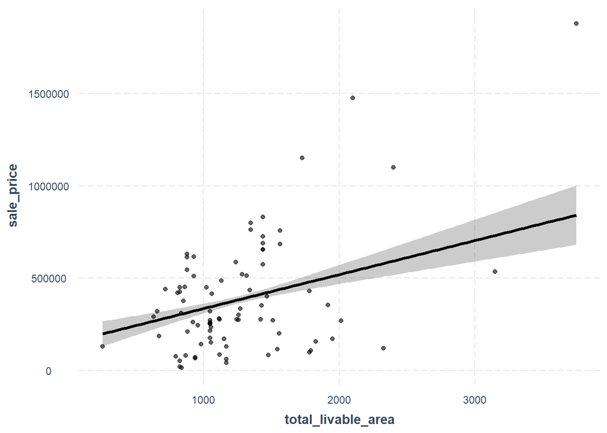

```r
## Plot of marginal response
effect_plot(reg1, pred = total_livable_area, interval = TRUE, plot.points = TRUE)
```

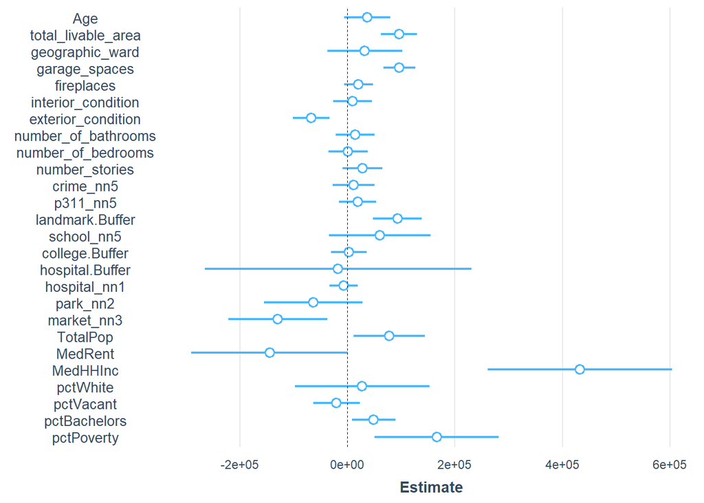

```r
## Plot coefficients
plot_summs(reg1, scale = TRUE)
```

## 4.3 Table of Goodness of Fit

Then we split Data into Train/Test Set.

```r
to_train <- to_train %>%
    mutate(landmark.Buffer = ifelse(is.na(landmark.Buffer), 0, landmark.Buffer))
to_train <- to_train %>%
    mutate(school.Buffer = ifelse(is.na(school.Buffer), 0, school.Buffer))
to_train <- to_train %>%
    mutate(college.Buffer = ifelse(is.na(college.Buffer), 0, college.Buffer))
to_train <- to_train %>%
    mutate(hospital.Buffer = ifelse(is.na(hospital.Buffer), 0, hospital.Buffer))
to_train <- to_train %>%
    mutate(park.Buffer = ifelse(is.na(park.Buffer), 0, park.Buffer))
to_train <- to_train %>%
    mutate(market.Buffer = ifelse(is.na(market.Buffer), 0, market.Buffer))

inTrain <- createDataPartition(
              y = paste(to_train$building_code_description, to_train$quality_grade),
              p = .60, list = FALSE)
philly.training <- to_train[inTrain,]
philly.test <- to_train[-inTrain,]

philly.training <- philly.training%>%
  dplyr::select(sale_price, Age, total_livable_area,
               geographic_ward,garage_spaces,fireplaces, interior_condition,exterior_condition,
               number_of_bathrooms, number_of_bedrooms, number_stories,
               toPredict, zip_code, geometry,
               crimes.Buffer, crime_nn1, crime_nn2, crime_nn3, crime_nn4, crime_nn5,
                 p311.Buffer, p311_nn1, p311_nn2, p311_nn3, p311_nn4, p311_nn5,
                 landmark.Buffer, landmark_nn1, landmark_nn2, landmark_nn3, landmark_nn4, landmark_nn5,
                 school.Buffer, school_nn1, school_nn2, school_nn3, school_nn4, school_nn5,
                 college.Buffer, college_nn1, college_nn2, college_nn3, college_nn4, college_nn5,
                 hospital.Buffer, hospital_nn1, hospital_nn2, hospital_nn3, hospital_nn4, hospital_nn5,
                 park.Buffer, park_nn1, park_nn2, park_nn3, park_nn4, park_nn5,
                 market.Buffer, market_nn1, market_nn2, market_nn3, market_nn4, market_nn5,
                 DIST_NAME,building_code_description, quality_grade, musaID)

philly.test <- philly.test%>%
  dplyr::select(sale_price, Age, total_livable_area,
               geographic_ward,garage_spaces,fireplaces, interior_condition,exterior_condition,
               number_of_bathrooms, number_of_bedrooms, number_stories,
               toPredict, zip_code, geometry,
               crimes.Buffer, crime_nn1, crime_nn2, crime_nn3, crime_nn4, crime_nn5,
                 p311.Buffer, p311_nn1, p311_nn2, p311_nn3, p311_nn4, p311_nn5,
                 landmark.Buffer, landmark_nn1, landmark_nn2, landmark_nn3, landmark_nn4, landmark_nn5,
                 school.Buffer, school_nn1, school_nn2, school_nn3, school_nn4, school_nn5,
                 college.Buffer, college_nn1, college_nn2, college_nn3, college_nn4, college_nn5,
                 hospital.Buffer, hospital_nn1, hospital_nn2, hospital_nn3, hospital_nn4, hospital_nn5,
                 park.Buffer, park_nn1, park_nn2, park_nn3, park_nn4, park_nn5,
                 market.Buffer, market_nn1, market_nn2, market_nn3, market_nn4, market_nn5,
                 DIST_NAME,building_code_description, quality_grade, musaID)

reg.training <-
  lm(sale_price ~ ., data = as.data.frame(philly.training) %>%
                             dplyr::select(sale_price, total_livable_area, Age,
                                           geographic_ward,garage_spaces,
                                           fireplaces, interior_condition,exterior_condition, number_of_bathrooms,
                                           number_of_bedrooms, number_stories,
                                           crime_nn5,p311_nn5,landmark.Buffer,
                                           school_nn5,college.Buffer,
                                           hospital.Buffer, hospital_nn1,
                                           park_nn2, market_nn3))

philly.test <-
  philly.test %>%
  na.omit()

philly.test <- philly.test %>%
  mutate(Regression = "Baseline Regression",
         sale_price.Predict = predict(reg.training, philly.test),
         sale_price.Error = sale_price.Predict - sale_price,
         sale_price.AbsError = abs(sale_price.Predict - sale_price),
         sale_price.APE = (abs(sale_price.Predict - sale_price)) / sale_price.Predict)%>%
  filter(sale_price < 5000000)

philly.test %>%
  st_drop_geometry() %>%
  summarise(MAE = mean(sale_price.AbsError),
            MAPE = mean(abs(sale_price.APE)*100)) %>%
  kbl(col.name=c('Mean Absolute Error','Mean Absolute Percentage Error')) %>%
  kable_classic()
```

[output not shown]

## 4.4 Cross Validation

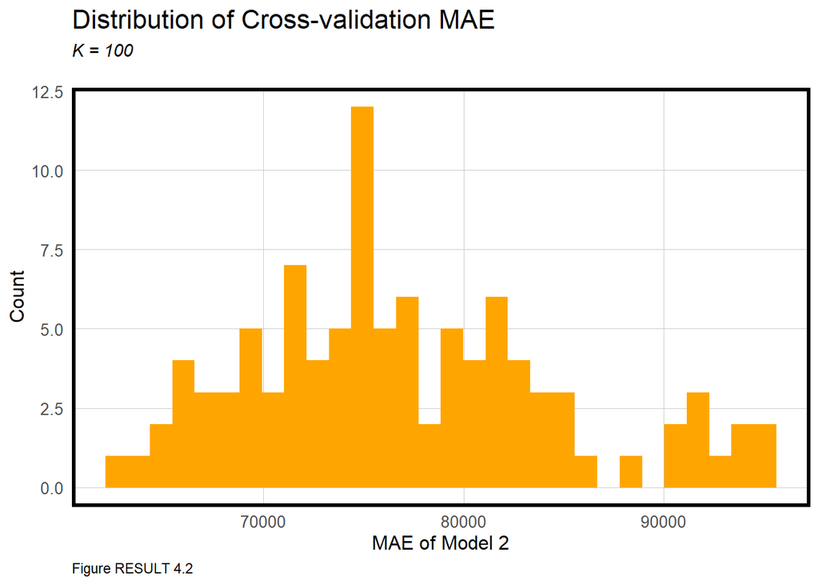

```r
fitControl <- trainControl(method = "cv", number = 100)
set.seed(825)

reg.cv <-
  train(sale_price ~ ., data = st_drop_geometry(to_train) %>%
          dplyr::select(sale_price, total_livable_area, Age,
                                           geographic_ward,garage_spaces,
                                           fireplaces, interior_condition,exterior_condition, number_of_bathrooms,
                                           number_of_bedrooms, number_stories,
                                           crime_nn5,p311_nn5,landmark.Buffer,
                                           school_nn5,college.Buffer,
                                           hospital.Buffer, hospital_nn1,
                                           park_nn2, market_nn3,
                                           DIST_NAME, TotalPop, MedRent ,MedHHInc, pctWhite, pctVacant, pctBachelors, pctPoverty),
        method = "lm", trControl = fitControl, na.action = na.pass)

ggplot(data = reg.cv$resample) +
  geom_histogram(aes(x = reg.cv$resample$MAE), fill = 'orange') +
  labs(title="Distribution of Cross-validation MAE",
       subtitle = "K = 100\n",
       caption = "Figure RESULT 4.2") +
  xlab('MAE of Model 2') +
  ylab('Count') +
  plotTheme()
```

## 4.5 Spatial Lags

```r
# predict competition
assign_test <- predict(reg.training , newdata=to_predict)
to_predict$predict <- assign_test
predicted_sub<-  to_predict %>%
  dplyr::select(musaID,predict) %>%
  mutate('team' = 'a team') %>%
  st_drop_geometry()
```

```r
# Remove invalid predictions (Maybe need to do this before running the test)
philly.test <-  philly.test[!with(philly.test,is.na(sale_price.Predict)),]
```

We create a list of “neigbhors” using a “spatial weights matrix”. As the price rises, the spatial lag of price also rises, which means our model is not so suitable for predicting high house price.

```r
coords <- st_coordinates(philly.test)

neighborList <- knn2nb(knearneigh(coords, 5))

spatialWeights <- nb2listw(neighborList, style="W")

philly.test$lagPrice <- lag.listw(spatialWeights, philly.test$sale_price)
```

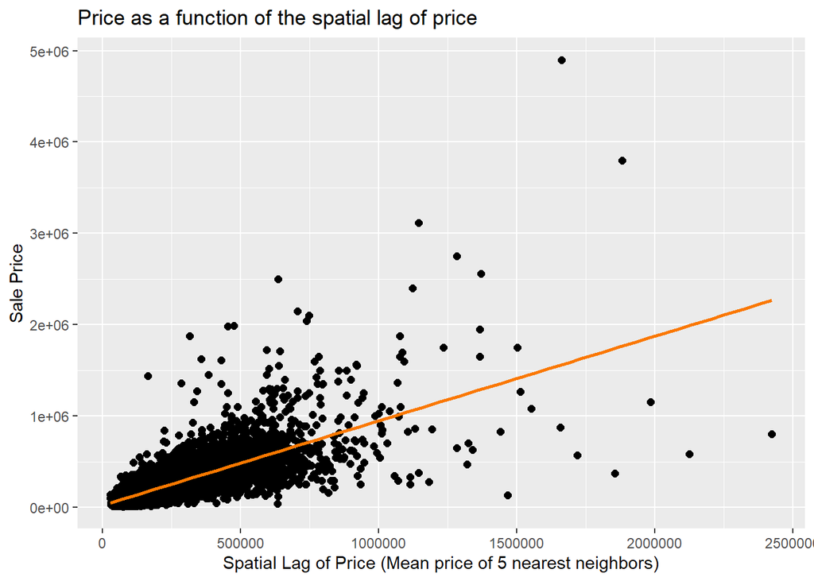

```r
coords.test <-  st_coordinates(philly.test)

neighborList.test <- knn2nb(knearneigh(coords.test, 5))

spatialWeights.test <- nb2listw(neighborList.test, style="W")

ggplot() +
  geom_point(data = philly.test, aes(x = lagPrice, y = sale_price), size = 2) +
  geom_smooth(data = philly.test, aes(x = lagPrice, y = sale_price), method = "lm", se = F, colour = "#FA7800") +
  labs(title = "Price as a function of the spatial lag of price",
       x = "Spatial Lag of Price (Mean price of 5 nearest neighbors)",
       y = "Sale Price")
```

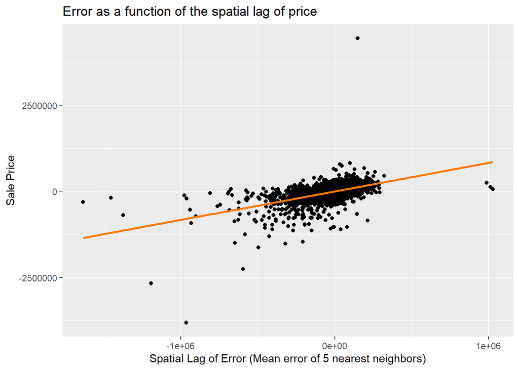

```r
philly.test %>%
  mutate(lagPriceError = lag.listw(spatialWeights.test, sale_price.Error)) %>%
  ggplot()+
  geom_point(aes(x =lagPriceError, y =sale_price.Error)) +
  geom_smooth(aes(x = lagPriceError, y = sale_price.Error),method = "lm", se=F, colour = "#FA7800") +
  labs(title = "Error as a function of the spatial lag of price",
       x = "Spatial Lag of Error (Mean error of 5 nearest neighbors)", y = "Sale Price")
```

## 4.5 Moran’s I

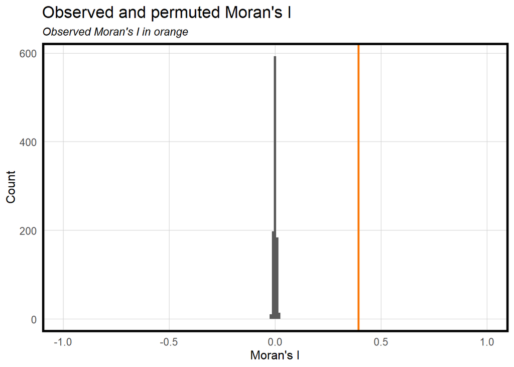

```r
moranTest <- moran.mc(philly.test$sale_price.Error,
                      spatialWeights.test, nsim = 999)

ggplot(as.data.frame(moranTest$res[c(1:999)]), aes(moranTest$res[c(1:999)])) +
  geom_histogram(binwidth = 0.01) +
  geom_vline(aes(xintercept = moranTest$statistic), colour = "#FA7800",size=1) +
  scale_x_continuous(limits = c(-1, 1)) +
  labs(title="Observed and permuted Moran's I",
       subtitle= "Observed Moran's I in orange",
       x="Moran's I",
       y="Count") +
  plotTheme()
```

## 4.6 Predictions by neighborhood

```r
philly.test %>%
as.data.frame() %>%
# Tract is not a good factor here
  group_by(DIST_NAME) %>%
    summarize(meanPrediction = mean(sale_price.Predict),
              meanPrice = mean(sale_price)) %>%
      kable() %>%
  kable_styling()
```

| DIST_NAME | meanPrediction | meanPrice |
| --- | --- | --- |
| Central | 410792.7 | 592088.60 |
| Central Northeast | 256711.1 | 275891.91 |
| Lower Far Northeast | 272397.3 | 285473.39 |
| Lower North | 242748.3 | 209333.45 |
| Lower Northeast | 199601.1 | 164859.58 |
| Lower Northwest | 377715.0 | 348128.58 |
| Lower South | 334767.7 | 495350.00 |
| Lower Southwest | 141628.1 | 125337.68 |
| North | 171682.5 | 91246.08 |
| North Delaware | 175725.3 | 205595.02 |
| River Wards | 209536.0 | 240381.93 |
| South | 293341.9 | 303528.76 |
| University Southwest | 275988.9 | 225915.76 |
| Upper Far Northeast | 282399.7 | 345444.79 |
| Upper North | 241622.0 | 172005.07 |
| Upper Northwest | 337652.9 | 277859.04 |
| West | 222371.7 | 155135.72 |
| West Park | 246550.8 | 187280.14 |

## 4.7 Regression with neighborhood effects

Then we ran the regression again, but this time with a neighborhood fixed effect.

```r
philly.training <- st_join(philly.training, acsTractsPHL.2020)

reg.nhood <-
  lm(sale_price ~ ., data = as.data.frame(philly.training) %>%
                             dplyr::select(sale_price, total_livable_area, Age,
                                           geographic_ward,garage_spaces,
                                           fireplaces, interior_condition,exterior_condition, number_of_bathrooms,
                                           number_of_bedrooms, number_stories,
                                           crime_nn5,p311_nn5,landmark.Buffer,
                                           school_nn5,college.Buffer,
                                           hospital.Buffer, hospital_nn1,
                                           park_nn2, market_nn3,
                                           DIST_NAME, TotalPop, MedRent ,MedHHInc, pctWhite, pctVacant, pctBachelors, pctPoverty))

philly.test <- st_join(philly.test, acsTractsPHL.2020)

philly.test.nhood <-
  philly.test %>%
  mutate(Regression = "Neighborhood Effects",
         sale_price.Predict = predict(reg.nhood, philly.test),
         sale_price.Error = sale_price.Predict- sale_price,
         sale_price.AbsError = abs(sale_price.Predict- sale_price),
         sale_price.APE = (abs(sale_price.Predict- sale_price)) / sale_price)%>%
  filter(sale_price < 5000000)
```

```r
philly.test.nhood$sale_price.Error <- replace(philly.test.nhood$sale_price.Error, is.na(philly.test.nhood$sale_price.Error), 9999999)
```

```r
bothRegressions <-
  rbind(
    dplyr::select(philly.test, starts_with("sale_price"), Regression, DIST_NAME) %>%
      mutate(lagPriceError = lag.listw(spatialWeights.test, sale_price.Error)),
    dplyr::select(philly.test.nhood, starts_with("sale_price"), Regression, DIST_NAME) %>%
      mutate(lagPriceError = lag.listw(spatialWeights.test, sale_price.Error)))

bothRegressions <- na.omit(bothRegressions)
```

```r
st_drop_geometry(bothRegressions) %>%
  gather(Variable, Value, -Regression, -DIST_NAME) %>%
  filter(Variable == "sale_price.AbsError" | Variable == "sale_price.APE") %>%
  group_by(Regression, Variable) %>%
    summarize(meanValue = mean(Value, na.rm = T)) %>%
    spread(Variable, meanValue) %>%
    kable()
```

| Regression | sale_price.AbsError | sale_price.APE |
| --- | --- | --- |
| Baseline Regression | 94790.19 | 0.3633398 |
| Neighborhood Effects | 72568.91 | 0.4195164 |

## 4.8 Predicted Map (Test Set)

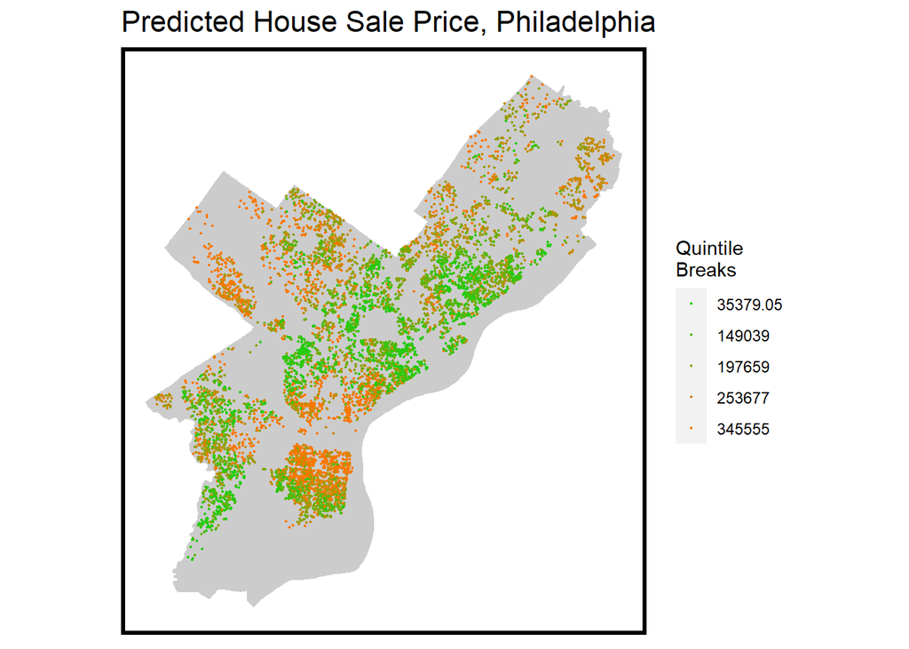

```r
 ggplot()+
   geom_sf(data= district,fill='grey80',color='transparent')+
   geom_sf(data = philly.test, aes(colour = q5(sale_price.Predict)),
          show.legend = "point", size = .35) +
   scale_colour_manual(values = palette5,
                  labels=qBr(philly.test,"sale_price.Predict"),
                   name="Quintile\nBreaks") +
  labs(title="Predicted House Sale Price, Philadelphia") +
  mapTheme()
```

## 4.9 plot of MAPE by neighborhood mean price

the Mean Absolute Percentage Error (MAPE) could provides a standardized measure of the housing price’s accuracy.

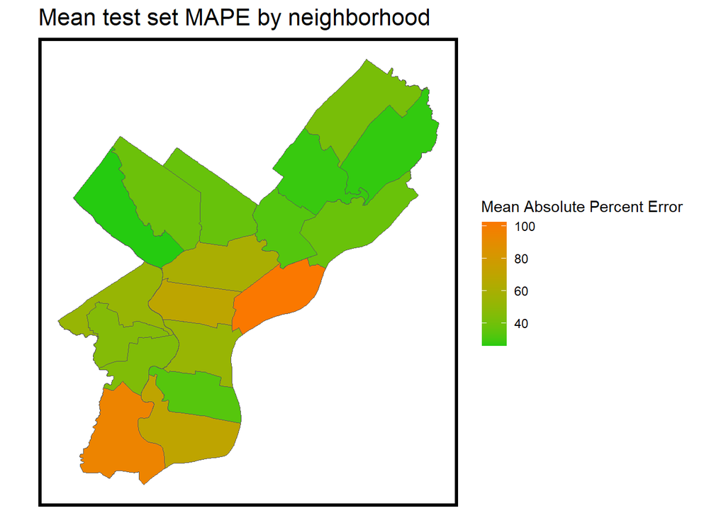

```r
st_drop_geometry(philly.test) %>%
  group_by(Regression, DIST_NAME) %>%
  summarize(mean.MAPE = mean(abs(sale_price.APE * 100), na.rm = T)) %>%
  ungroup() %>%
  left_join(district) %>%
    st_sf() %>%
    ggplot() +
      geom_sf(aes(fill = mean.MAPE)) +
      scale_fill_gradient(low = palette5[1], high = palette5[5],
                          name = "Mean Absolute Percent Error") +
      labs(title = "Mean test set MAPE by neighborhood") +
      mapTheme()
```